# Lab 3: Linear Regression and Statistical Inference

Author

Feng Qiu, Liyuan Xuan

Published

September 29, 2025

## 1 Preparation

### 1.1 Installing and Loading Packages

```r
# load packages that might be used in this section

# install.packages(c("broom", "knitr", "car"))  # use this line to install the necessary packages

library(broom)  # to extract summary information into a tidy data frame
library(knitr)  # for better visualization of tables
library(car)    # for hypothesis testing
```

### 1.2 Read in External Data

```r
# read in data

setwd("D:/Dropbox/Teaching/AREC513/Fall2025/materials/data/ch2_data_csv")
wage <- read.csv(file = "wages1.csv") # make sure you are in the correct working directory

# alternatively, you can do
# wage <- read.csv(file = "YOUR_FOLDER_PATH/wages1.csv")

head(wage)
```

```
  exper male school     wage
1     9    0     13 6.315296
2    12    0     12 5.479770
3    11    0     11 3.642170
4     9    0     14 4.593337
5     8    0     14 2.418157
6     9    0     14 2.094058
```

## 2 Summary Statistics

```r
sum_table_1 <- summary(wage)
sum_table_1
```

```
     exper             male            school           wage
 Min.   : 1.000   Min.   :0.0000   Min.   : 3.00   Min.   : 0.07656
 1st Qu.: 7.000   1st Qu.:0.0000   1st Qu.:11.00   1st Qu.: 3.62157
 Median : 8.000   Median :1.0000   Median :12.00   Median : 5.20578
 Mean   : 8.043   Mean   :0.5237   Mean   :11.63   Mean   : 5.75758
 3rd Qu.: 9.000   3rd Qu.:1.0000   3rd Qu.:12.00   3rd Qu.: 7.30451
 Max.   :18.000   Max.   :1.0000   Max.   :16.00   Max.   :39.80892
```

```r
sum_table_2 <- tidy(wage)
sum_table_2
```

```
# A tibble: 4 × 13
  column     n   mean    sd median trimmed   mad    min   max range    skew
  <chr>  <dbl>  <dbl> <dbl>  <dbl>   <dbl> <dbl>  <dbl> <dbl> <dbl>   <dbl>
1 exper   3294  8.04  2.29    8      8.04   1    1       18    17    0.155
2 male    3294  0.524 0.500   1      0.530  0    0        1     1   -0.0948
3 school  3294 11.6   1.66   12     11.7    1    3       16    13   -0.394
4 wage    3294  5.76  3.27    5.21   5.42   1.84 0.0766  39.8  39.7  1.97
# ℹ 2 more variables: kurtosis <dbl>, se <dbl>
```

```r
sum_table_3 <- sum_table_2[, c(1, 2, 3, 4, 8, 9, 10, 11)]
# or, try sum_table_3 <- sum_table_2[, c("column", "n", "mean", "sd", "min", "max", "range", "skew")]
sum_table_3
```

```
# A tibble: 4 × 8
  column     n   mean    sd    min   max range    skew
  <chr>  <dbl>  <dbl> <dbl>  <dbl> <dbl> <dbl>   <dbl>
1 exper   3294  8.04  2.29  1       18    17    0.155
2 male    3294  0.524 0.500 0        1     1   -0.0948
3 school  3294 11.6   1.66  3       16    13   -0.394
4 wage    3294  5.76  3.27  0.0766  39.8  39.7  1.97
```

```r
kable(sum_table_3, caption = "Descriptive Statistics", digits = 2)
```

Descriptive Statistics

| column | n | mean | sd | min | max | range | skew |
| --- | --- | --- | --- | --- | --- | --- | --- |
| exper | 3294 | 8.04 | 2.29 | 1.00 | 18.00 | 17.00 | 0.15 |
| male | 3294 | 0.52 | 0.50 | 0.00 | 1.00 | 1.00 | -0.09 |
| school | 3294 | 11.63 | 1.66 | 3.00 | 16.00 | 13.00 | -0.39 |
| wage | 3294 | 5.76 | 3.27 | 0.08 | 39.81 | 39.73 | 1.97 |

To acquire summary statistics by group, you can do

```r
# wage rate by gender
tapply(wage$wage, wage$male, summary)
```

```
$`0`
    Min.  1st Qu.   Median     Mean  3rd Qu.     Max.
 0.07656  3.17564  4.69326  5.14692  6.53275 32.49740

$`1`
   Min. 1st Qu.  Median    Mean 3rd Qu.    Max.
 0.1535  4.0290  5.6543  6.3130  7.8913 39.8089
```

## 3 Ordinary Least Squares (OLS) Regression

### 3.1 Simple Linear Regression

```r
# estimate a simple OLS
mod1 <- lm(wage ~ male, data = wage)
sum_mod1 <- summary(mod1)
print(sum_mod1)
```

```
Call:
lm(formula = wage ~ male, data = wage)

Residuals:
   Min     1Q Median     3Q    Max
-6.160 -2.102 -0.554  1.487 33.496

Coefficients:
            Estimate Std. Error t value Pr(>|t|)
(Intercept)  5.14692    0.08122   63.37   <2e-16 ***
male         1.16610    0.11224   10.39   <2e-16 ***
---
Signif. codes:  0 '***' 0.001 '**' 0.01 '*' 0.05 '.' 0.1 ' ' 1

Residual standard error: 3.217 on 3292 degrees of freedom
Multiple R-squared:  0.03175,   Adjusted R-squared:  0.03145
F-statistic: 107.9 on 1 and 3292 DF,  p-value: < 2.2e-16
```

```r
# return names of "mod1", so you can extract the output you need via "$"
names(mod1)
```

```
 [1] "coefficients"  "residuals"     "effects"       "rank"
 [5] "fitted.values" "assign"        "qr"            "df.residual"
 [9] "xlevels"       "call"          "terms"         "model"
```

```r
mod1$coefficients
```

```
(Intercept)        male
   5.146924    1.166097
```

```r
names(sum_mod1)
```

```
 [1] "call"          "terms"         "residuals"     "coefficients"
 [5] "aliased"       "sigma"         "df"            "r.squared"
 [9] "adj.r.squared" "fstatistic"    "cov.unscaled"
```

```r
sum_mod1$coefficients
```

```
            Estimate Std. Error  t value    Pr(>|t|)
(Intercept) 5.146924 0.08122482 63.36639 0.00000e+00
male        1.166097 0.11224216 10.38912 6.71263e-25
```

### 3.2 Multiple Linear Regression

```r
# estimate a multiple OLS
mod2 <- lm(wage ~ male + school + exper, data = wage)
sum_mod2 <- summary(mod2)
print(sum_mod2, signif = F)  # significance asterisk removed
```

```
Call:
lm(formula = wage ~ male + school + exper, data = wage)

Residuals:
   Min     1Q Median     3Q    Max
-7.654 -1.967 -0.457  1.444 34.194

Coefficients:
            Estimate Std. Error t value Pr(>|t|)
(Intercept) -3.38002    0.46498  -7.269 4.50e-13
male         1.34437    0.10768  12.485  < 2e-16
school       0.63880    0.03280  19.478  < 2e-16
exper        0.12483    0.02376   5.253 1.59e-07

Residual standard error: 3.046 on 3290 degrees of freedom
Multiple R-squared:  0.1326,    Adjusted R-squared:  0.1318
F-statistic: 167.6 on 3 and 3290 DF,  p-value: < 2.2e-16
```

```r
# extract the goodness of fit
gof <- c(r.squared = sum_mod2$r.squared, adj.r = sum_mod2$adj.r.squared)
gof
```

```
r.squared     adj.r
0.1325877 0.1317968
```

## 4 Results of OLS Regressions

### 4.1 Variance-Covariance Matrix

Recall a typical variance-covariance matrix, showing variance along the diagonal and covariance off the diagonal.

$$\text{Var}[X] =
\begin{bmatrix}
\text{Var}(X_1) & \text{Cov}(X_1, X_2) & \text{Cov}(X_1, X_3) & \cdots & \text{Cov}(X_1, X_n) \\
\vdots & \text{Var}(X_2) & \text{Cov}(X_2, X_3) & \cdots & \text{Cov}(X_2, X_n) \\
\vdots & \vdots & \text{Var}(X_3) & \cdots & \text{Cov}(X_3, X_n) \\
\vdots & \vdots & \vdots & \ddots & \vdots \\
\text{Cov}(X_n, X_1) & \text{Cov}(X_n, X_2) & \text{Cov}(X_n, X_3) & \cdots & \text{Var}(X_n)
\end{bmatrix}$$

```r
# acquire the variance-covariance matrix
vcv2 <- vcov(mod2)
vcv2
```

```
             (Intercept)          male        school         exper
(Intercept)  0.216203148 -0.0077905379 -0.0138223376 -0.0060354002
male        -0.007790538  0.0115940968  0.0003412493 -0.0002797278
school      -0.013822338  0.0003412493  0.0010755674  0.0001410101
exper       -0.006035400 -0.0002797278  0.0001410101  0.0005646688
```

```r
var_male <- vcv2[2, 2]
var_male
```

```
[1] 0.0115941
```

```r
se_male <- sqrt(var_male) # check the standard error of beta_male
se_male
```

```
[1] 0.1076759
```

```r
cov_male_school <- vcv2[2, 3]  # or vcv2[3, 2]
cov_male_school
```

```
[1] 0.0003412493
```

### 4.2 Confidence Interval

Recall the formula for the confidence interval:

$$CI_{1-\alpha}=[\hat{\beta_i} - t_{1-\alpha/2,df} \times SE(\hat{\beta_i}), \hat{\beta_i} + t_{1-\alpha/2,df} \times SE(\hat{\beta_i})]$$

#### 4.2.1 Calculate Confidence Interval using `confint()`

```r
ci <- confint(mod2)
ci
```

```
                  2.5 %     97.5 %
(Intercept) -4.29169078 -2.4683456
male         1.13325010  1.5554872
school       0.57449537  0.7031000
exper        0.07823415  0.1714167
```

**Note**

`confint()` has to be used on a fitted model object, such as “mod2” (rather than “sum_mod2”). For details, check `?confint()`.

#### 4.2.2 Calculate Confidence Interval Manually

```r
beta <- sum_mod2$coefficients[, 1]
se_beta <- sum_mod2$coefficients[, 2]

deg_f <- mod2$df.residual
alpha <- 0.05
t_crit <-  qt(1 - alpha / 2, deg_f)

lower_bound <- beta - t_crit * se_beta
upper_bound <- beta + t_crit * se_beta

ci_manual <- matrix(c(lower_bound, upper_bound), nrow = 4, ncol = 2,
                     dimnames = list(c(names(lower_bound)), # assigning row names to the new matrix
                                     c(colnames(ci)))       # assigning col names
                    )
ci_manual
```

```
                  2.5 %     97.5 %
(Intercept) -4.29169078 -2.4683456
male         1.13325010  1.5554872
school       0.57449537  0.7031000
exper        0.07823415  0.1714167
```

**Tip**

As we saw earlier, `qt(p, df)` is used to extract critical values for the t distribution, the “q” here means quantile function. Explore other related functions for the t distribution as, `dt(x, df)` for density, `pt(q, df)` for distribution function, and `rt(n, df)` for random generation.

Similarly:

- For the F distribution, `df(x, df1, df2)`, `pf(q, df1, df2)`, `qf(p, df1, df2)`, and `rf(n, df1, df2)`.
- For the $\chi^2$ distribution, `dchisq(x, df)`, `pchisq(q, df)`, `qchisq(p, df)`, and `rchisq(n, df)`.
- For the normal distribution, `dnorm(x)`, `pnorm(q)`, `qnorm(p)`, and `rnorm(n)`.

### 4.3 Hypothesis Testing

Recall the general process of hypothesis testing (two-tailed) for coefficients, for example, testing if $\beta_i$ equals a certain constant $c$

$$H_0:\beta_i = c$$
$$H_1:\beta_i \neq c$$
The calculation of the test statistic is
$$t = \frac{\hat{\beta_i}-c}{SE(\hat{\beta_i})}$$
The test statistic is then compared with the critical values of the t distribution $t^*_{\alpha/2, df}$, at specified significance level $\alpha$ and degree of freedom.

- $H_0$ is rejected, if $|t| \geq t^*_{\alpha/2, df}$
- $H_0$ is not rejected, if $|t| < t^*_{\alpha/2, df}$

Suppose we wish to test if $H_0:\beta_{school} = 0.5$ against $H_1:\beta_{school} \neq 0.5$ at 5% significance level:

#### 4.3.1 Calculate t Statistics Manually

```r
beta_school <- sum_mod2$coefficients[3, 1]
se_school <- sum_mod2$coefficients[3, 2]
t_stat <- (beta_school - 0.5) / se_school

t_stat >= t_crit
```

```
[1] TRUE
```

#### 4.3.2 Hypothesis Testing using `linearHypothesis()`

Enabled by the package “car”, `linearHypothesis()` can also be used to hypothesis testing.

```r
linearHypothesis(mod2, "school = 0.5")  # check the critical value for F stat using qf(1 - alpha, 3291, 3290)
```

```
Linear hypothesis test:
school = 0.5

Model 1: restricted model
Model 2: wage ~ male + school + exper

  Res.Df   RSS Df Sum of Sq      F    Pr(>F)
1   3291 30694
2   3290 30528  1     166.2 17.911 2.378e-05 ***
---
Signif. codes:  0 '***' 0.001 '**' 0.01 '*' 0.05 '.' 0.1 ' ' 1
```

**Important**

Since `linearHypothesis()` performs an F test, it can also be used for testing on multiple variables. Try `linearHypothesis(mod2, "school = male")`.

## 5 Prediction with Linear Regression

Given our fitted model “mod2”, we can now use it to perform prediction. Suppose we wish to predict the wage per hour for

1. A male and a female worker with 16 years of schooling
2. Other variables (i.e. “exper”) are kept at the average level

```r
pred_data <- data.frame(male = c(female = 0, male = 1),
                        school = 16,
                        exper = mean(wage$exper)
                        )
pred_data
```

```
       male school    exper
female    0     16 8.043412
male      1     16 8.043412
```

```r
yhat <- predict(mod2, pred_data)
yhat
```

```
  female     male
7.844768 9.189136
```

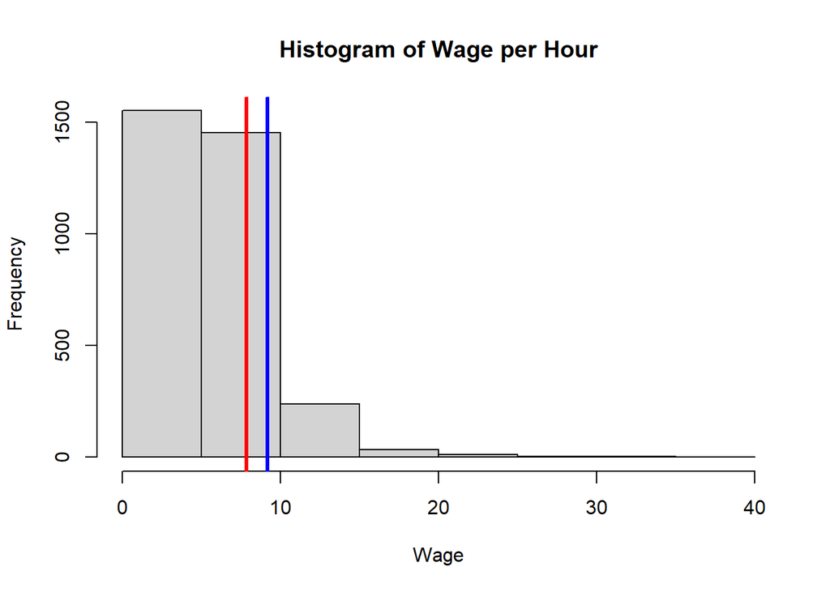

```r
# visualizing the prediction
hist(wage$wage, xlab = "Wage", main = "Histogram of Wage per Hour")
abline(v = yhat, col = c("red", "blue"), lwd = 3)
```

## 6 Exercise

Continue from your multiple linear regression “mod2”:

1. Calculate the R-squared using $y_i$ and $\hat{y}_i$, that is
   $$R^2 = corr(y_i, \hat{y}_i)^2$$
   (tip: you can retrieve the fitted values $\hat{y}_i$ via `mod2$fitted.values`.)
2. Construct the confidence interval for $\hat{\beta}_{male}$, with the significance level of 10%.
3. Test $H_0:\beta_{exper} = 0.15$, with the significance level of 10%.
4. Test $H_0:\beta_{school} + \beta_{exper} = 0.75$, with the significance level of 1%.
5. Predict the wage per hour for a male worker with 18 years of schooling and 0 years of experience.